# Práctica II

Análisis clúster

Jairo Garcia (DNI Z0020363J) (Universidad Complutense de Madrid)  
2023-01-26

```r
# Ajuste comunes de los chunk
knitr::opts_chunk$set(fig.width = 9, fig.asp = 1, out.width = "100%",
                      message = FALSE, warning = FALSE,
                      echo = TRUE, res = 400)
```

# Instrucciones (leer antes de empezar)

- Modifica dentro del documento `.Rmd` tus datos personales (nombre y DNI) ubicados en la cabecera del archivo.
- Asegúrate antes de seguir editando el documento que el archivo `.Rmd` compila (Knit) correctamente y se genera el `html` correspondiente.
- Los chunks creados están o vacíos o incompletos, de ahí que tengan la opción `eval = FALSE`. Una vez que edites lo que consideres debes de cambiar a `eval = TRUE` para que los chunk se ejecuten

## Paquetes necesarios

Necesitaremos los siguientes paquetes:

- **Manejo de datos**: paquete `{tidyverse}`.
- **Modelos**: paquete `{tidymodels}`
- **Lectura excel**: paquete `{readxl}`
- **Resumen numérico**: paquete `{skimr}`.
- **Visualización de clústers y PCA**: paquete `{factoextra}` y `{FactoMineR}`
- **Clustering divisivo**: paquete `{cluster}`

```r
# Borramos variables del environment
rm(list = ls())
library(tidyverse)
library(tidymodels)
library(readxl)
library(skimr)
library(factoextra)
library(FactoMineR)
library(cluster)
library(corrplot)
library(scales)
```

# Carga de datos

El archivo de datos a usar será `provincias.xlsx`

```r
provincias <- read_xlsx(path = "./provincias.xlsx")
```

El fichero contiene **información socioeconómica de las provincias españolas**

```r
glimpse(provincias)
```

```
Rows: 52
Columns: 19
$ Prov          <chr> "Albacete", "Alicante", "Almería", "Álava", "A~
$ Poblacion     <dbl> 396987, 1868438, 701688, 321932, 1061756, 6909~
$ Mortalidad    <dbl> 9.41, 8.00, 6.91, 7.72, 12.16, 9.54, 7.08, 8.1~
$ Natalidad     <dbl> 9.02, 8.52, 11.41, 10.26, 6.26, 8.96, 9.51, 9.~
$ IPC           <dbl> 101.819, 102.309, 101.454, 102.743, 102.070, 1~
$ NumEmpresas   <dbl> 26701, 130438, 40327, 19548, 67451, 39640, 871~
$ Industria     <dbl> 3332, 9992, 2191, 2048, 3496, 3059, 4413, 2741~
$ Construccion  <dbl> 3428, 17418, 5388, 2669, 8435, 4599, 14485, 50~
$ CTH           <dbl> 11111, 52720, 18184, 7557, 28045, 18420, 30644~
$ Infor         <dbl> 189, 1851, 366, 323, 787, 332, 1403, 11134, 15~
$ AFS           <dbl> 624, 2745, 944, 354, 1445, 948, 1627, 8829, 16~
$ APT           <dbl> 3278, 19865, 5840, 3341, 10598, 5235, 16444, 8~
$ TasaActividad <dbl> 57.72, 58.21, 60.63, 57.86, 51.42, 56.00, 68.6~
$ TasaParo      <dbl> 23.28, 23.39, 31.08, 13.33, 16.97, 29.63, 13.8~
$ Ocupados      <dbl> 144.8, 687.1, 234.4, 133.0, 389.0, 224.6, 555.~
$ PIB           <dbl> 7235991, 32139347, 11909684, 10716021, 2177043~
$ CANE          <dbl> 20888, 25968, 22945, 3691, 23910, 37438, 10748~
$ TVF           <dbl> 215948, 1274096, 395086, 155767, 613905, 37249~
$ VS            <dbl> 30244, 326705, 72486, 9791, 73250, 49441, 8571~
```

Algunas de las variables son:

- `Prov`: nombre de la provincia
- `Poblacion`: habitantes
- `Mortalidad`, `Natalidad`: tasa de mortalidad/natalidad (en tantos por mil)
- `IPC`: índice de precios de consumo (sobre un valor base de 100).
- `NumEmpresas`: número de empresas.
- `PIB`: producto interior bruto
- `CTH`: coyuntura turística hotelera (pernoctaciones en establecimientos hoteleros)

# Ejercicio 1:

> Calcula la matriz de covarianzas y de correlaciones. Usa el paquete `{corrplot}` para una representación gráfica de la misma. Detalla y comenta lo que consideres para su correcta interpretación.

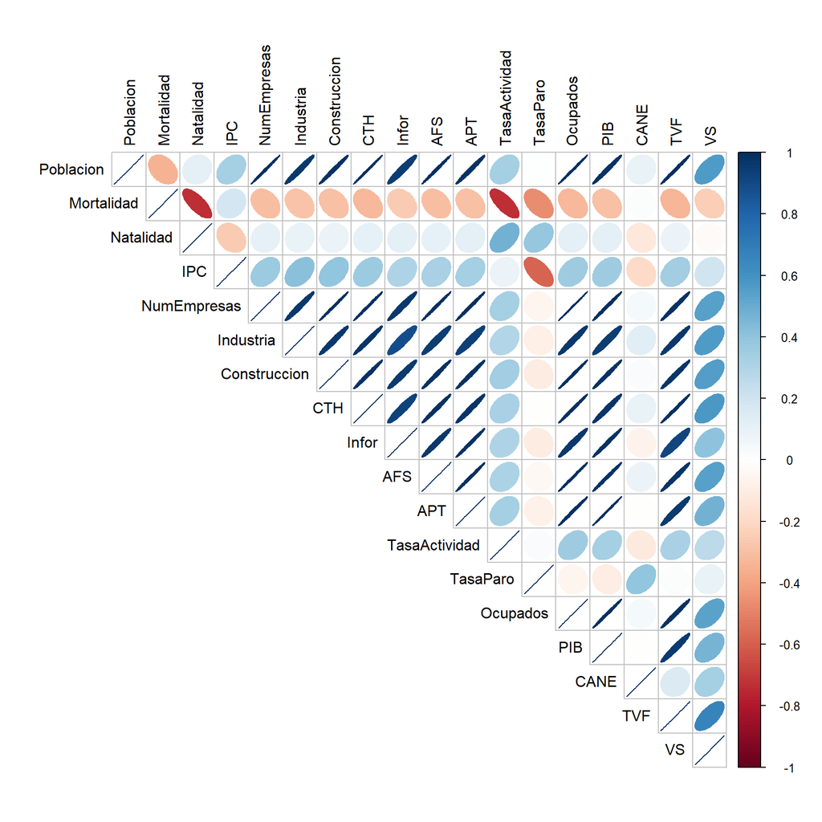

```r
# Completa el código y cambia a eval = TRUE

# Matriz de covarianzas
cov_mat <- cov(provincias %>% select(where(is.numeric)))

# Matriz de correlaciones
cor_mat <- cor(provincias %>% select(where(is.numeric)))


corrplot(cor_mat, type = "upper",
          tl.col = "black",  method = "ellipse")
```

> Dándole un vistazo al grafico anterior podemos deducir que hay una gran cantidad de correlación entre las variables, así que es probable que se pueda prescindir de algunas de ellas.

# Ejercicio 2:

> Estandariza los datos por rango y guardalos en provincias_scale

```r
provincias_scale <-
  provincias %>% mutate(across(where(is.numeric), rescale))
```

# Ejercicio 3:

> Calcula con `eigen()` los autovalores y autovectores de la matriz de correlaciones e interpreta dichos resultados en relación a las componentes principales de las variables originales. Detalla todo lo que consideres

```r
# Completa el código
autoelementos <- eigen(cov_mat)
autoelementos
```

```
eigen() decomposition
$values
 [1] 1.075562e+15 7.355225e+10 3.653702e+09 1.809962e+08 1.280339e+08
 [6] 2.977185e+07 2.968182e+06 6.819123e+05 4.543882e+05 1.026489e+05
[11] 1.784126e+04 1.328339e+04 8.944125e+01 1.628989e+01 5.773457e+00
[16] 1.650647e+00 3.941844e-01 2.505021e-01

$vectors
               [,1]          [,2]          [,3]          [,4]
 [1,]  3.452909e-02 -8.164530e-01  5.275419e-01 -1.924495e-01
 [2,] -1.911976e-08  1.910956e-06 -7.051117e-06  6.293436e-05
 [3,]  7.423248e-09  1.579579e-07  7.454141e-06 -4.731216e-05
 [4,]  8.878377e-09  1.403383e-07 -2.126861e-06  3.646407e-06
 [5,]  2.733381e-03 -4.035470e-02 -7.003684e-03  5.890353e-02
 [6,]  1.388377e-04 -3.782164e-03 -1.977152e-03  4.160240e-02
```

[output cut: 88 more lines]

# Ejercicio 4:

> Haciendo uso de `PCA()` del paquete `{FactoMineR}` calcula todas las componentes principales. Repite de nuevo el análisis con el mínimo número de componentes necesairas para capturar al menos el 95% de la información de los datos.

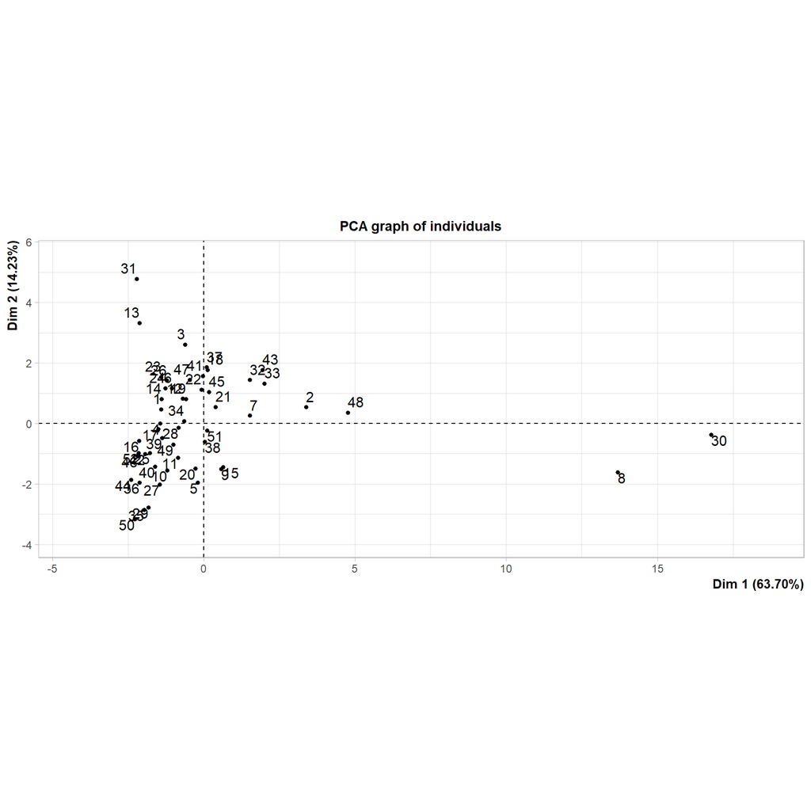

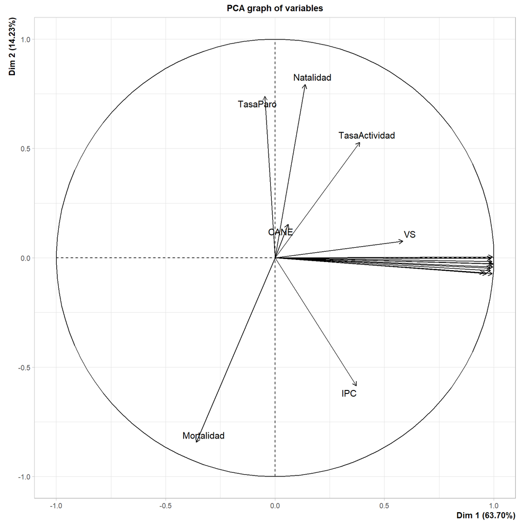

```r
pca_fit <-
    PCA(provincias %>% select(where(is.numeric)), scale.unit = TRUE , ncp = 18, graph = TRUE)
```

```r
pca_full <- provincias_scale %>% select(-Prov)
```

# Ejercicio 5:

> Realiza las gráficas que consideres más útiles para poder interpretar adecuadamente las componentes principales obtenidas. ¿Cuál es la expresión para calcular la primera componente en función de las variables originales?

```r
# Completa el código

# Detalla todo lo que consideres sobre las constribuciones de cada
# variable a cada componente.
pca_fit$ind$contrib
```

```
          Dim.1        Dim.2        Dim.3        Dim.4        Dim.5
1  3.335161e-01 1.683468e-01  0.010884580  0.431812974  0.072238583
2  1.920203e+00 2.188047e-01  4.332233585 12.061117057 15.814435065
3  6.374602e-02 5.131811e+00  0.050779419  0.041307233  0.007410641
4  3.498501e-01 5.356197e-07  4.858412705  0.026336391  0.922019555
5  6.945512e-03 2.863495e+00  1.982324010  1.049273903  0.572329645
6  1.843649e-01 1.024200e+00  3.794103569  1.502982835  0.023975190
7  3.906623e-01 5.081303e-02  7.468854821 11.501527456  0.973976739
8  3.139876e+01 1.951924e+00  0.884203258  0.159751482  4.554467720
9  5.572928e-02 1.708366e+00  1.638078840  0.301318465  2.684089458
10 2.422433e-01 1.803519e+00  0.935427162  2.011943029  1.525665373
11 1.209128e-01 9.521455e-01  0.415695718  0.331329032  0.072011805
12 7.982023e-02 5.061378e-01  0.315956579  0.299942232  1.264614946
13 7.574954e-01 8.307648e+00  3.860077428  2.792736743  0.374211711
14 3.250621e-01 4.990990e-01  3.893325829  1.233089809  0.197381310
```

[output cut: 197 more lines]

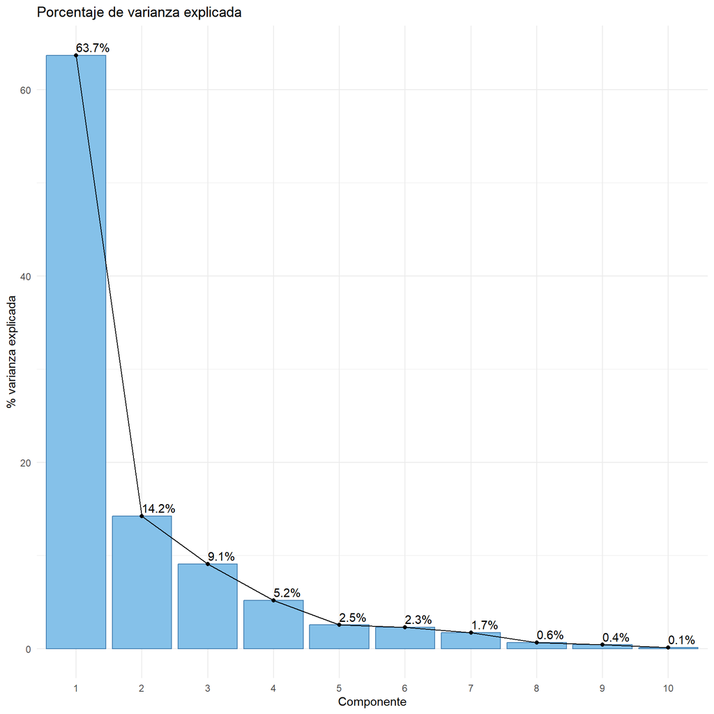

```r
fviz_eig(pca_fit,
         barfill = "#85C1E9",
         addlabels = TRUE) +
  theme_minimal() +
  labs(x = "Componente",
       y = "% varianza explicada",
       title = "Porcentaje de varianza explicada")
```

```r
print(pca_fit$svd$V)
```

```
             [,1]         [,2]         [,3]        [,4]         [,5]
 [1,]  0.29352698  0.002493342  0.049947340 -0.05339540  0.015898841
 [2,] -0.10629199 -0.527120141  0.188867032 -0.16131678 -0.024146585
 [3,]  0.04062702  0.495419403 -0.270681171 -0.10967036  0.382061614
 [4,]  0.10991169 -0.365322291 -0.262317619  0.43504738  0.556757431
 [5,]  0.29418239 -0.026147510  0.007952241 -0.06913798  0.006367061
 [6,]  0.28562283 -0.044737470  0.046369149  0.02345108  0.150042973
 [7,]  0.29326489 -0.045381770 -0.012082096 -0.02639413 -0.008113738
 [8,]  0.29286608 -0.010617503  0.048841149 -0.02758090  0.028366126
 [9,]  0.28150192 -0.042018125 -0.064640257 -0.22152688 -0.070433510
[10,]  0.29246592 -0.016454205  0.039554303 -0.09168100 -0.003041574
[11,]  0.29072490 -0.029433207 -0.028068230 -0.14186101 -0.031732816
[12,]  0.11433729  0.330614591 -0.362734482  0.46305159 -0.133043722
[13,] -0.01399634  0.461562171  0.387356995 -0.22020186  0.055362718
[14,]  0.29442838 -0.016838806  0.002429338 -0.06005252  0.001232463
```

[output cut: 80 more lines]

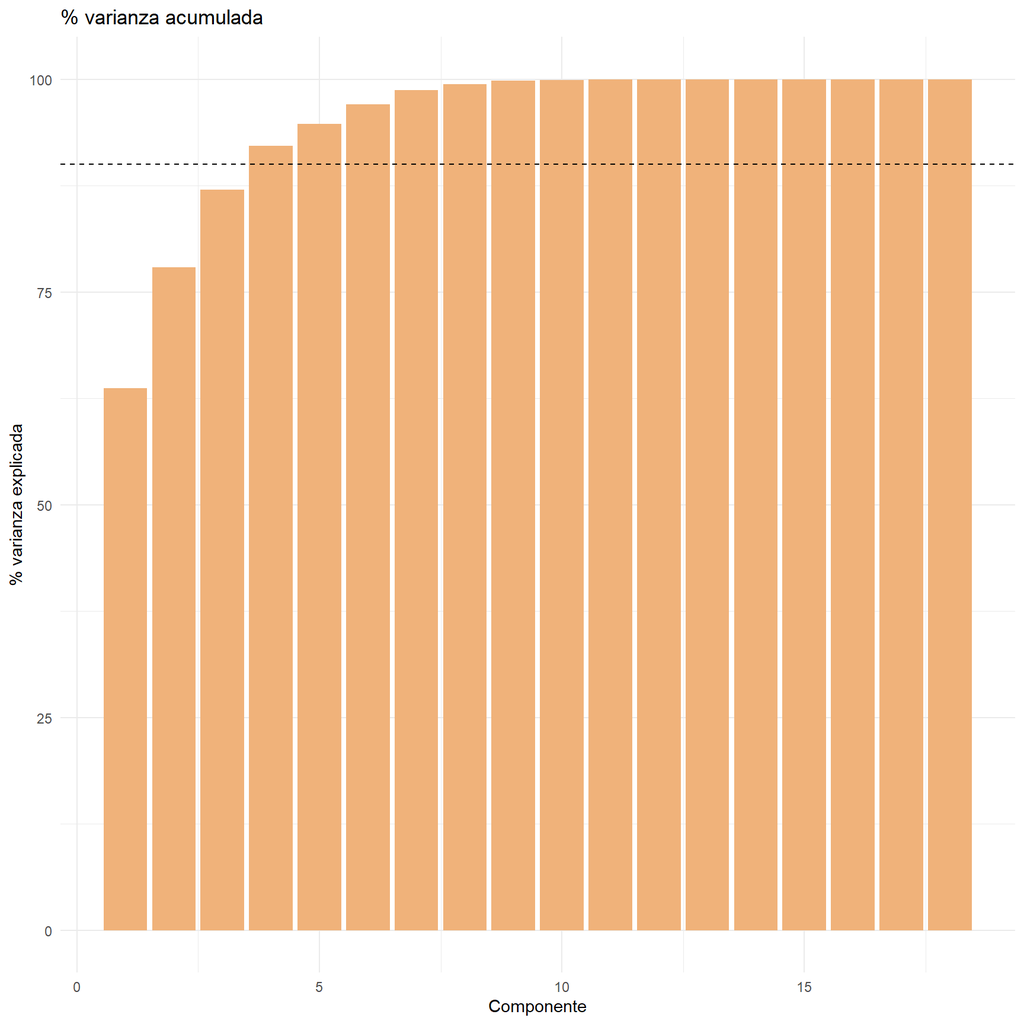

```r
# > Construye un gráfico para visualizar la varianza explicada acumulada
# > (con una línea horizontal que nos indica el umbral del 95%)

cumvar <- as_tibble(pca_fit$eig)
names(cumvar) <- c("autovalor", "var", "cumvar")

ggplot(cumvar, aes(x = 1:18, y = cumvar)) +
  geom_col(fill = "#F0B27A") +
  geom_hline(yintercept = 90,
             linetype = "dashed") +
  theme_minimal() +
  labs(x = "Componente",
       y = "% varianza explicada",
       title = "% varianza acumulada")
```

# Ejercicio 6:

> ¿Cuál es la contribución de las variables originales en cada componente principal seleccionada? Proporciona las nuevas coordenadas de los datos. ¿Cuál de las variables es la que está peor explicada?

```r
#Contribucion de cada variable a las componentes
pca_fit$var$contrib
```

```
                   Dim.1        Dim.2        Dim.3       Dim.4
Poblacion     8.61580869 6.216756e-04 2.494737e-01  0.28510690
Mortalidad    1.12979868 2.778556e+01 3.567076e+00  2.60231048
Natalidad     0.16505544 2.454404e+01 7.326830e+00  1.20275871
IPC           1.20805785 1.334604e+01 6.881053e+00 18.92662230
NumEmpresas   8.65432772 6.836923e-02 6.323813e-03  0.47800598
Industria     8.15804006 2.001441e-01 2.150098e-01  0.05499531
Construccion  8.60042932 2.059505e-01 1.459770e-02  0.06966501
CTH           8.57705398 1.127314e-02 2.385458e-01  0.07607058
Infor         7.92433313 1.765523e-01 4.178363e-01  4.90741583
AFS           8.55363151 2.707409e-02 1.564543e-01  0.84054061
APT           8.45209684 8.663137e-02 7.878255e-02  2.01245468
TasaActividad 1.30730170 1.093060e+01 1.315763e+01 21.44167757
TasaParo      0.01958975 2.130396e+01 1.500454e+01  4.84888573
Ocupados      8.66880711 2.835454e-02 5.901685e-04  0.36063054
PIB           8.46269279 1.307379e-01 1.405631e-01  1.78508842
CANE          0.03164342 9.251454e-01 4.313115e+01  7.75029908
TVF           8.50111166 2.558733e-04 9.952426e-01  0.19487506
VS            2.97022035 2.286851e-01 8.418293e+00 32.16259720
                     Dim.5        Dim.6        Dim.7        Dim.8
Poblacion     2.527731e-02  0.008577510  0.453944293  0.246968635
Mortalidad    5.830576e-02  0.113808680  3.786678534 45.865436885
Natalidad     1.459711e+01  9.825724095 34.577279772  6.566809467
IPC           3.099788e+01 12.301662219 10.785093429  2.143526238
NumEmpresas   4.053946e-03  0.004628499  0.027361631  0.001888042
Industria     2.251289e+00  0.379668213  0.419007777  7.685410328
Construccion  6.583274e-03  0.003921397  0.070969785  0.090355580
CTH           8.046371e-02  0.223154480  0.464317190  1.157164098
Infor         4.960879e-01  1.577980441  0.263865387  6.229380990
AFS           9.251174e-04  0.299366263  0.034286589  0.516264301
APT           1.006972e-01  0.640893842  0.006486645  1.558033658
TasaActividad 1.770063e+00 27.932330747  3.462400720 13.746861359
TasaParo      3.065031e-01  9.253743706 34.975747546 11.795755341
Ocupados      1.518964e-04  0.159122519  0.055008212  0.003181954
PIB           7.434893e-03  0.593372087  0.008014071  0.318075815
CANE          2.381808e+01 17.575176869  3.985286690  0.018186776
TVF           2.178721e-01  0.543501985  0.003119205  0.488797237
VS            2.526122e+01 18.563366447  6.621132525  1.567903296
                     Dim.9       Dim.10       Dim.11       Dim.12
Poblacion      0.403656111 1.225602e+01  3.468181374 2.930211e+00
```

[output cut: 40 more lines]

```
IPC           1.729371e-03 4.011722e-05
NumEmpresas   4.658536e+00 6.095188e+01
Industria     8.368365e-02 2.904591e-01
Construccion  1.023485e+00 6.797538e-01
CTH           1.555915e+01 1.217247e+01
Infor         1.041706e+01 7.260297e-01
AFS           4.059301e-01 5.213426e-02
APT           2.725248e+01 2.143626e+01
TasaActividad 1.840140e-03 5.741280e-03
TasaParo      1.126135e-04 3.556412e-03
Ocupados      2.695980e+01 1.239595e+00
PIB           3.397665e-01 7.588082e-01
CANE          1.317719e-03 1.141685e-03
TVF           1.651943e-03 6.020702e-01
VS            3.639765e-05 1.903701e-03
```

```r
#Nuevas coordenadas de los datos
pca_fit$ind$coord
```

```
         Dim.1         Dim.2       Dim.3       Dim.4       Dim.5
1  -1.41017686  0.4734423651  0.09617150 -0.45796713  0.13095494
2   3.38367603  0.5397505581  1.91865320  2.42036146 -1.93760003
3  -0.61651226  2.6139666809  0.20772292 -0.14164444 -0.04194355
4  -1.44429594 -0.0008444871 -2.03183179 -0.11310052  0.46785078
5  -0.20350137 -1.9525986131  1.29786007 -0.71388934 -0.36860431
6  -1.04846596  1.1677693270  1.79554023 -0.85440440  0.07544289
7   1.52621574  0.2601071540 -2.51922849  2.36354690  0.48085217
8  13.68268794 -1.6121155618 -0.86679541 -0.27855369  1.03981506
9   0.57644373 -1.5081871153 -1.17979880 -0.38255980  0.79824422
10 -1.20182455 -1.5496195139 -0.89154966  0.98854013  0.60182044
11 -0.84908539 -1.1259429948 -0.59433092  0.40115869 -0.13074923
12 -0.68987702  0.8209167732  0.51814851  0.38168516 -0.54791911
13 -2.12522644  3.3258586141 -1.81108385 -1.16466618  0.29805470
14 -1.39218950  0.8151885534  1.81886692 -0.77389817  0.21646631
```

[output cut: 197 more lines]

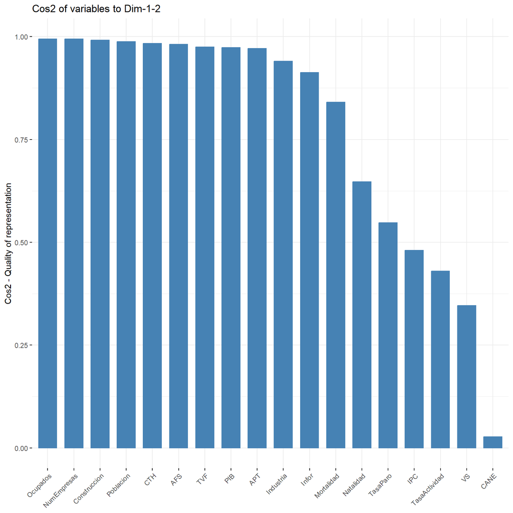

```r
fviz_cos2(pca_fit,barfill = "#85C1E9", choice = "var", axes = 1:2)
```

> Basado en el Grafico anterior podemos notar que “CANE” es la variable peor explicada

# Ejercicio 7:

> Si tuviéramos que construir un “índice” que valore de forma conjunta el desarrollo económico de una provincia, ¿cómo se podría construir utilizando una combinación lineal de todas las variables? ¿A qué correspondería de lo que hemos visto? ¿Cuál sería el valor de dicho índice en Madrid? ¿Cual sería su valor en Melilla?

```r
# Completa el código
A <- c()
for (i in 1:52) A[i] <- sum(pca_fit$svd$V[,1]*pca_full[i,])
A <- rescale(A)

provincias_range <- provincias_scale %>%   mutate(indice = A)

provincias_range
```

```
# A tibble: 52 x 20
   Prov   Pobla~1 Morta~2 Natal~3   IPC NumEm~4 Indus~5 Const~6    CTH
   <chr>    <dbl>   <dbl>   <dbl> <dbl>   <dbl>   <dbl>   <dbl>  <dbl>
 1 Albac~  0.0491   0.420  0.252  0.293  0.0455  0.119   0.0526 0.0581
 2 Alica~  0.280    0.255  0.216  0.411  0.251   0.363   0.288  0.324
 3 Almer~  0.0969   0.128  0.425  0.205  0.0725  0.0774  0.0856 0.103
 4 Álava   0.0373   0.222  0.342  0.515  0.0313  0.0722  0.0398 0.0354
 5 Astur~  0.153    0.742  0.0515 0.353  0.126   0.125   0.137  0.166
 6 Badaj~  0.0952   0.436  0.247  0.105  0.0711  0.109   0.0723 0.105
 7 Balea~  0.160    0.148  0.287  0.829  0.165   0.159   0.239  0.183
 8 Barce~  0.854    0.276  0.297  1      0.866   1       0.850  0.984
 9 Bizka~  0.168    0.467  0.218  0.691  0.147   0.190   0.177  0.185
10 Burgos  0.0443   0.548  0.159  0.786  0.0427  0.0628  0.0564 0.0495
# ... with 42 more rows, 11 more variables: Infor <dbl>, AFS <dbl>,
#   APT <dbl>, TasaActividad <dbl>, TasaParo <dbl>, Ocupados <dbl>,
#   PIB <dbl>, CANE <dbl>, TVF <dbl>, VS <dbl>, indice <dbl>, and
#   abbreviated variable names 1: Poblacion, 2: Mortalidad,
#   3: Natalidad, 4: NumEmpresas, 5: Industria, 6: Construccion
```

> ¿Cuál sería el valor de dicho índice en Madrid?

```r
provincias_range$indice[30]
```

```
[1] 1
```

> ¿Cual sería su valor en Melilla?

```r
provincias_range$indice[31]
```

```
[1] 0.01271209
```

# Ejercicio 8:

> Calcula la matriz de distancias de los datos. Representa un mapa de calor de la matriz de datos, estandarizado y sin estandarizar, así como de la matriz de distancias. Comenta si se detectan inicialmente grupos de provincias.

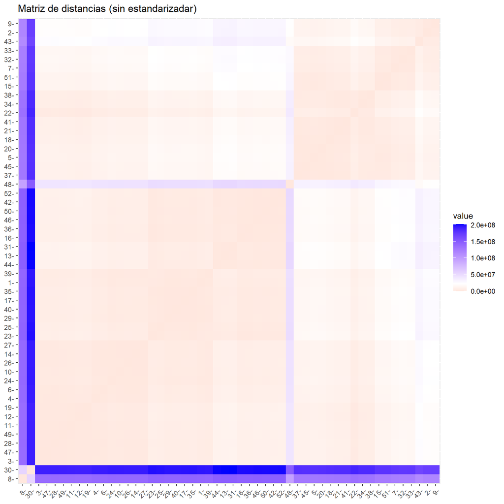

```r
#Matriz de distancias. en "Method" le indico el tipo de metrica, el codigo


dse <- dist(provincias %>%
            mutate(across(where(is.numeric))),
          method = "euclidean")

d <- dist(provincias_scale %>% select(-Prov),
          method = "euclidean")


#Matriz sin Estandarizar
fviz_dist(dse, show_labels = TRUE) +
  labs(title = "Matriz de distancias (sin estandarizadar)")
```

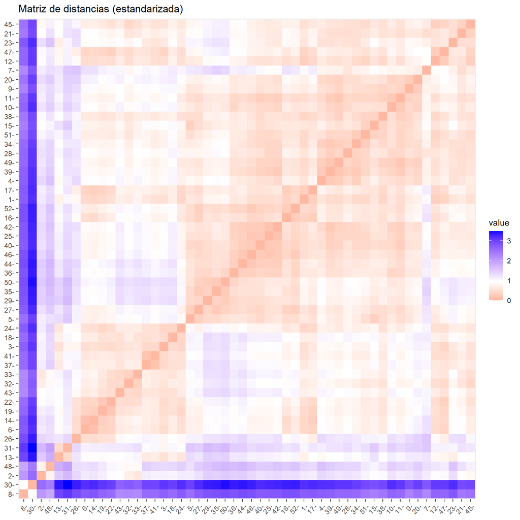

```r
#Matriz Estandarizada
fviz_dist(d, show_labels = TRUE)  +
  labs(title = "Matriz de distancias (estandarizada)")
```

> En la Grafica de la matriz estandarizada podemos apreciar entre 3 y cuatro grupos.

# Ejercicio 9:

> Realiza varios análisis de clúster jerárquico con distintos enlaces y comenta las diferencias. En cada caso visualiza el dendograma y comenta cuántos clusters recomendarías usar.

> Jairo: Los comentarios los hare dentro del codigo

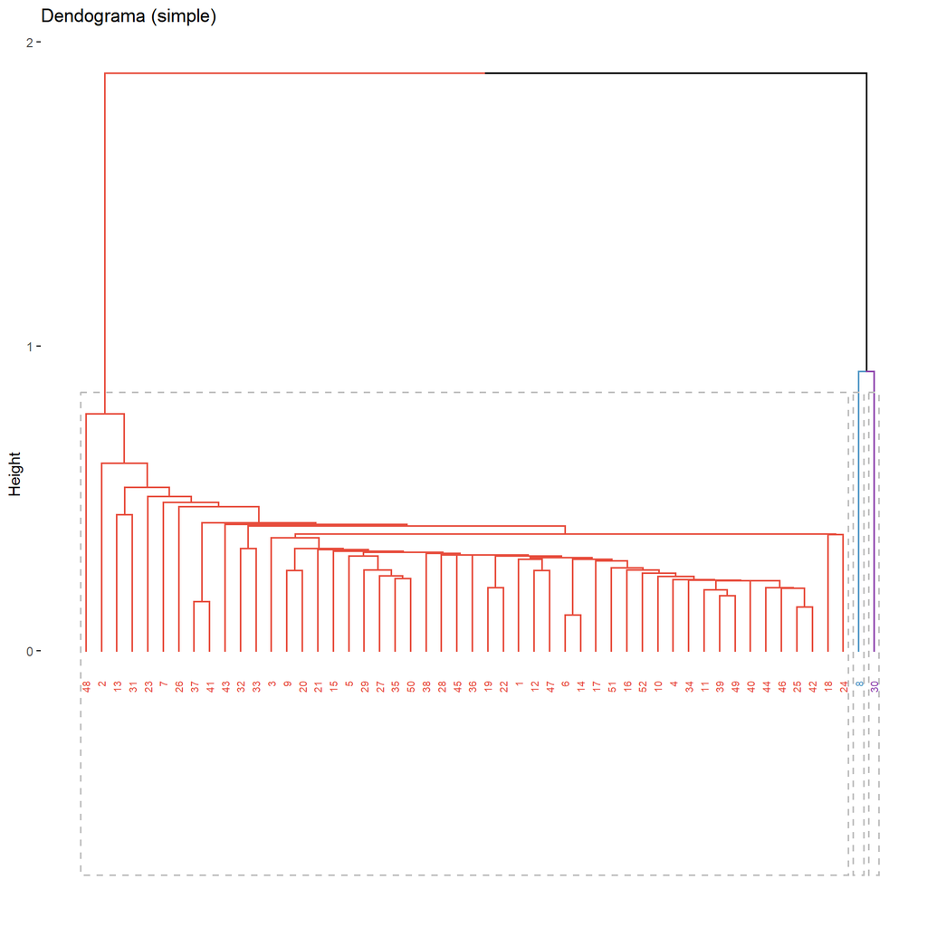

```r
# Completa el código
# Dendograma (simple)
# Ya que en este se pueden notar mmayoria en ciertos grupos, es mejor optar solo por 3
single_clust <- hclust(d, method = "single")
fviz_dend(single_clust,
          k = 3,
          cex = 0.5,
          k_colors =
            c("#E74C3C", "#5499C7",
              "#8E44AD"),
          color_labels_by_k = TRUE,
          rect = TRUE) +
  labs(title = "Dendograma (simple)")
```

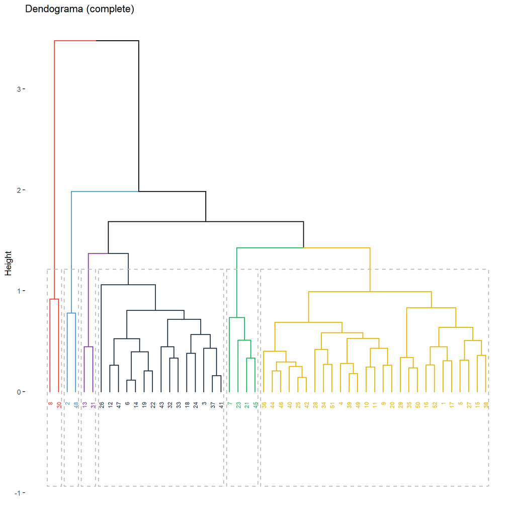

```r
#Dendograma (complete) | Clustering (complete

complete_clust <- hclust(d, method = "complete")

#para los este 6 ya que hay mas grupos
fviz_dend(complete_clust, k = 6,
          cex = 0.5,
          k_colors =
            c("#E74C3C", "#5499C7", "#8E44AD", "#273746", "#28B463", "#E7B800"),
          # Diferentes colores a los clusters
          color_labels_by_k = TRUE,
          #añade un rectángulo alrededor
          rect = TRUE) +
  labs(title = "Dendograma (complete)")
```

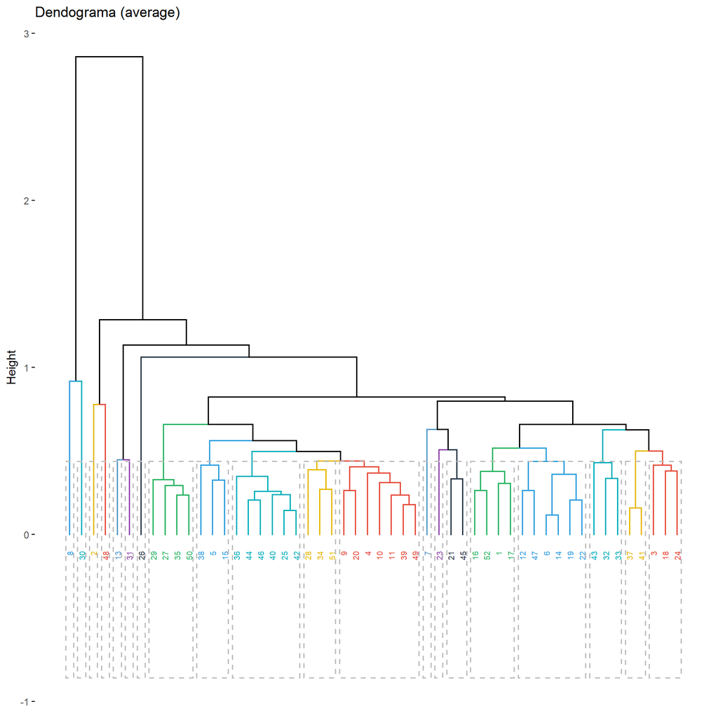

```r
#Para poder apreciar mejor, en este caso 20 sera un numero adecuado.

#Dendograma (average)
average_clust <-
  hclust(d, method = "average")


fviz_dend(average_clust, k = 20,
          cex = 0.5,
          k_colors =
            c("#2E9FDF", "#00AFBB", "#E7B800","#E74C3C", "#5499C7", "#8E44AD", "#273746", "#28B463"),
          # Diferentes colores a los clusters
          color_labels_by_k = TRUE,
          #añade un rectángulo alrededor
          rect = TRUE) +
  labs(title = "Dendograma (average)")
```

# Ejercicio 10:

> ¿Qué número óptimo de clusters nos indican los criterios Silhoutte y de Elbow? Representar los individuos agrupados según el número de clusters elegido.

> Una vez ejecutado el codigo, se puede notar en los graficos que el numero de clusters optimo es 3, notese que la variablididad decrementa despues de este.

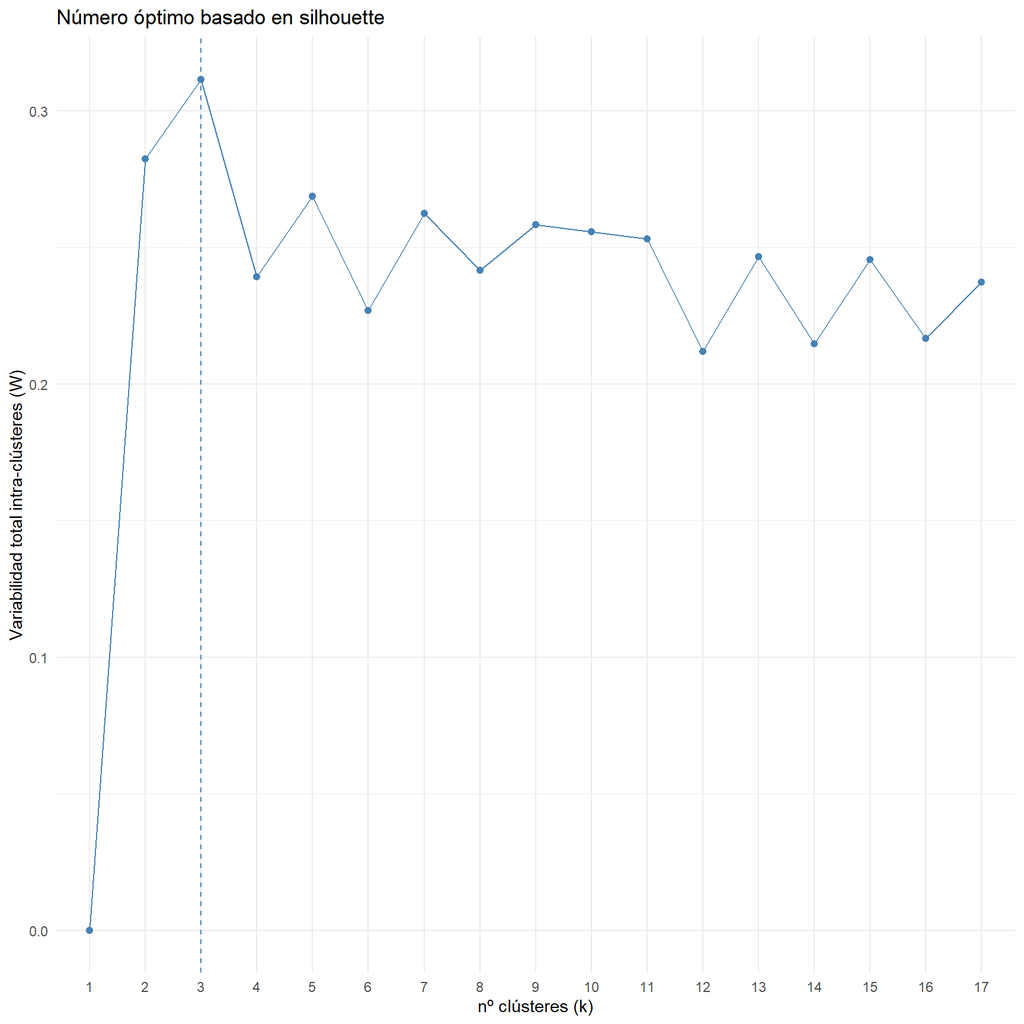

```r
kclust <- kmeans(provincias_scale %>% select(-Prov),
                 centers = 3, iter.max = 50)

fviz_nbclust(provincias_scale %>% select(-Prov), kmeans,
             method = "silhouette", k.max = 17) +
  theme_minimal() +
  labs(x = "nº clústeres (k)",
       y = "Variabilidad total intra-clústeres (W)",
       title = "Número óptimo basado en silhouette")
```

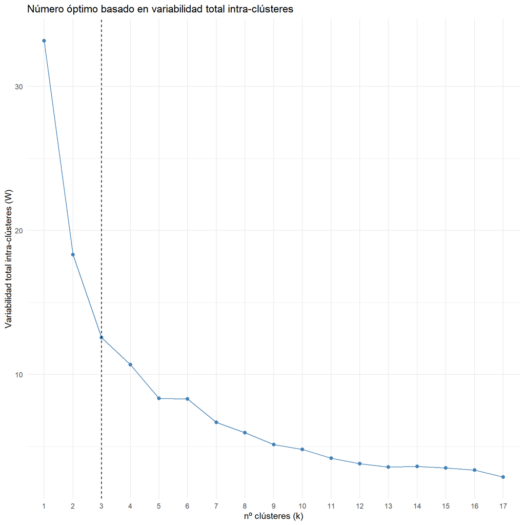

```r
fviz_nbclust(provincias_scale %>% select(-Prov),
             kmeans, method = "wss", k.max = 17) +
  geom_vline(xintercept = 3, linetype = 2) +
  theme_minimal() +
  labs(x = "nº clústeres (k)",
       y = "Variabilidad total intra-clústeres (W)",
       title = "Número óptimo basado en variabilidad total intra-clústeres")
```

```r
silho <- silhouette(kclust$cluster, d)
silho
```

```
      cluster neighbor   sil_width
 [1,]       3        2 -0.08464602
 [2,]       3        2  0.12645346
 [3,]       3        2  0.37934458
 [4,]       2        3  0.34629495
 [5,]       2        3  0.36418517
 [6,]       3        2  0.26632920
 [7,]       2        3  0.11879924
 [8,]       1        3  0.64494881
 [9,]       2        3  0.40559500
[10,]       2        3  0.46565505
[11,]       2        3  0.48662116
[12,]       3        2  0.03317428
[13,]       3        2  0.19783334
[14,]       3        2  0.22361336
```

[output cut: 44 more lines]

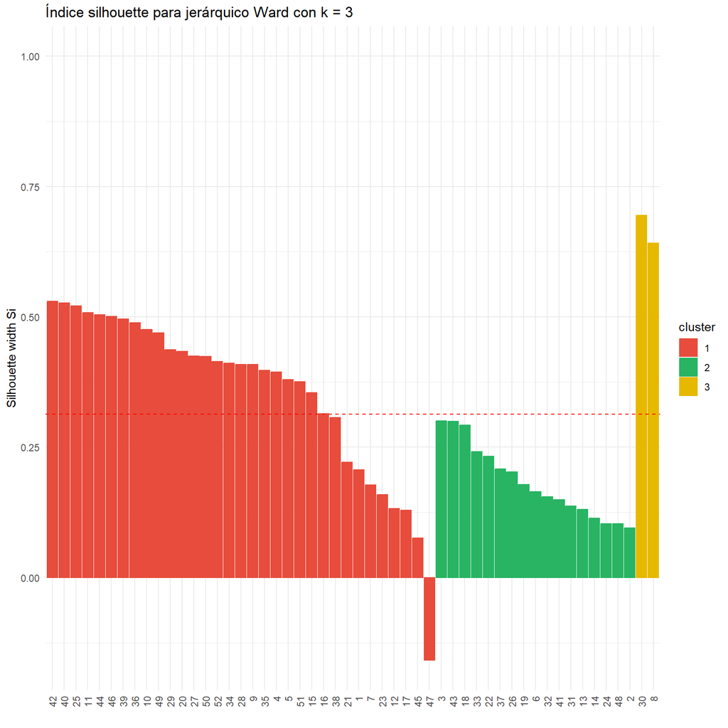

```r
# Clustering (ward)
ward_clust <-
  hclust(d, method = "ward.D2")
groups <- cutree(ward_clust, k = 3)
sil <- silhouette(groups, d)
#row.names(sil) <- row.names(esperanza_scale_df)
# Visualización
fviz_silhouette(sil, label = TRUE,
                print.summary = FALSE) +
  scale_fill_manual(values =
                      c("#E74C3C", "#28B463",
                        "#E7B800")) +
  scale_color_manual(values =
                      c("#E74C3C", "#28B463",
                        "#E7B800")) +
  theme_minimal() +
  labs(title =
         "Índice silhouette para jerárquico Ward con k = 3") +
  # Giramos etiquetas eje
  theme(axis.text.x =
          element_text(angle = 90,
                       vjust = 0.5,
                       hjust = 1))
```

# Ejercicio 11:

> Con el número de clusters decidido en el apartado anterior realizar un agrupamiento no jerárquico de k-medias. Representar los clusters formados en los planos de las Componentes principales. Interpreta los resultados y evalúa la calidad del análisis clúster. Explica las provincias que forman cada uno de los clusters y comentar cuales son las características socioeconómicas que las hacen pertenecer a dicho cluster

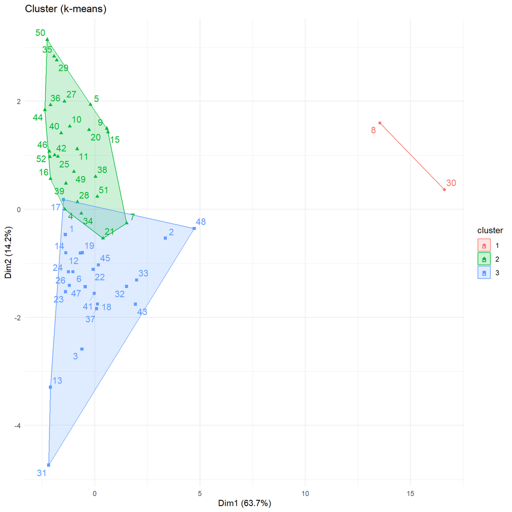

```r
kclust <- kmeans(provincias_scale %>% select(-Prov),
                 centers = 3, iter.max = 54)

fviz_cluster(list(data =
                    provincias_scale %>% select(-Prov),
                  cluster = kclust$cluster),
             ellipse.type = "convex",
             repel = TRUE,
             show.clust.cent = FALSE) +
  labs(title = "Cluster (k-means)") +
  theme_minimal()
```

> De el lado derecho podemos encontrar a madrid y barcelona ciudades con mayor desarrollo donde la economia y el acceso a los estudios superiores es mayor, caso contrario de las provincias que encontramos el cluster azul.